# PROJECT 2

### $\color{red}{\text{Any kind of plagiarism (help from your friends or getting help from internet or AI) is prohibited. }}$Submit $\color{red}{\text{only}}$ your jupyter notebook file to elearn.

### Introduction

In this project, you will work with a real geospatial dataset of U.S. state boundaries, which can be used for agricultural planning and analysis. Although the dataset contains many states, you will focus only on Tennessee, Kentucky, Alabama, and Georgia as sample agricultural fields. These selected regions will serve as the basis for your analysis, where you will calculate area, assign crop yield values, and estimate total harvest. For the yield calculations, use the following (fake but realistic) yield values in tons per hectare:

```
Tennessee: 7.5
Kentucky: 8.2
Alabama: 6.8
Georgia: 7.0
```

### Dataset

The dataset is a GeoJSON file containing polygon boundaries for U.S. states, where each polygon represents a geographic region with its name and shape. In this project, these regions are treated as agricultural fields, allowing us to calculate area and estimate crop harvest based on assigned yield values.

```python
#PERSONAL NOTES BELOW
# For assign crop yield values use yield values in tons per hectare above ^ .
# Need to calculate: area , assign crop yield values, and need to estimate total harvest.
#Only data needed from Tennessee,Kentucky,Alabama and Georgia .
```

### Your Code

```
         name     Land Area  total_harvest_tons
0     Alabama  1.336376e+07        9.087357e+07
10    Georgia  1.528124e+07        1.069687e+08
17   Kentucky  1.046964e+07        8.585105e+07
42  Tennessee  1.093173e+07        8.198795e+07
```

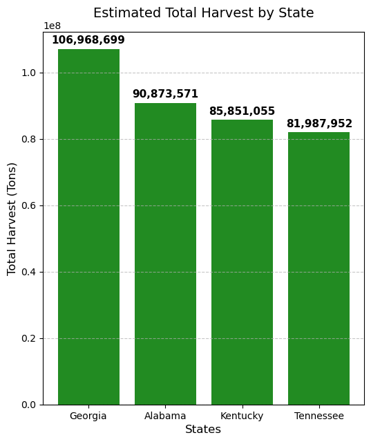

```python
# The imports
import geopandas as gpd
import matplotlib.pyplot as plt

#loading in the GeoJson DataSet
gdf = gpd.read_file("data.geojson")

# Fixing the CRS so i can calculate the are GeoJSON files, since this file is in WGS84 which is lat/long
gdf = gdf.to_crs(epsg=32616)  # Converting the CRS to meters

# Calculating the surface area in square meters from the converted map (epsg:32616).
gdf['area_m2'] = gdf.geometry.area

# Restricting the yield values in the dictionary
yield_mapping = {
    "Tennessee": 7.5, "Kentucky": 8.2, "Alabama": 6.8, "Georgia": 7.0

}
# Calculating the hectares (1 H is equal to 10k sq meters), needed to convert since the map coords were in meters and the given yield values are in hectares. "tons per hectare" so the math had to add up.
gdf['Land Area'] = gdf.geometry.area / 10000

# Shortcut for a manual for loop (How? : This line looks up each state name in the dictionary and copies the matching yield value into a new column for that row.)
gdf['yield_per_hectare'] = gdf['name'].map(yield_mapping)

# Filtering the data, by making a subset (' .isin ' is the/a filter)
gdf_filtered = gdf[gdf["name"].isin(yield_mapping.keys())].copy()

#Calculating total harvest by going row by row.
gdf_filtered['total_harvest_tons'] = gdf_filtered['Land Area'] * gdf_filtered['yield_per_hectare']

# Results
print(gdf_filtered[['name', 'Land Area', 'total_harvest_tons']])





# To get a better visual I choose to make a bar graph so I can see a comparison up close and not miss details and to form good observations

# To make it in order
gdf_filtered = gdf_filtered.sort_values('total_harvest_tons', ascending=False)
# Set the figure size
plt.figure(figsize=(6, 7))

# Create the bar chart from the filtered data
bars = plt.bar(gdf_filtered['name'], gdf_filtered['total_harvest_tons'], color='forestgreen')

# Add data labels on top of each bar
for bar in bars:
    yval = bar.get_height()
    # f"{yval:,.0f}" formats the number with commas and zero decimals (e.g., 152,431)
    plt.text(bar.get_x() + bar.get_width()/2, yval + (yval * 0.01), f"{yval:,.0f}",
             ha='center', va='bottom', fontweight='bold', fontsize=11)

# Add titles and labels
plt.title('Estimated Total Harvest by State', fontsize=14, pad=15)
plt.xlabel('States', fontsize=12)
plt.ylabel('Total Harvest (Tons)', fontsize=12)

# Added a light grid to make the values easier to track
plt.grid(axis='y', linestyle='--', alpha=0.7)

plt.show()
```

## Please add all the code above and answer these questions:

Question 1 Which field has the highest estimated harvest?

Question 2 Which field has the lowest estimated harvest?

Question 3 Why do we convert to another CRS before calculating area?

Your answers to the questions:

```python
# Q1: Georgia can be seen to have the highest estimated harvest in the bar graph. It is a good thing the bar graph made me take a closer look at the results. They have the highest because of the number the gdf.geomerty.area calculated when i converted the epsg: 32616 into meters then to hectares. Then the 7.0  times it really made it soar above the rest

# Q2: Tennessee had the lowest estimation because it has a smaller land area than the two highest estimates, the high yield that was higher than the highest est couldnt save it just because the difference was just too great.

# Q3: Its a to must convert the CRS because WGS84 is a goegraphic coordinates which is (Long/Lat). If I do not convert it, it will misreport the calculations it got from the dataset. Since degrees change physical size depending on where you are on the globe, they cannot be used for accurate area calculations. Using meters helps the system calculate square meters accurately across large goegraphical regions


#PERSONAL CONCLUSION/Analysis  : Read like a paragraph
#With the high yield states like Kentucky and Tennessee and high-volume states like Georgia and Alabama these 4 make a pretty good region.
#I say this because based based on the U.S. Drought Monitor from Jan 13, 2026, Alabama and Georgia are seen to have more severe droughts than Tennessee and Kentucky.
#Because this is a well-balanced region, the smaller states could act as a safety net to ensure the total harvest doesn't drop significantly
```